# Project 3 - Pandas & Seaborn 201

## Task 5. Analyze & Answer Questions (Part II)

1. Explore the target variable: Create a bar chart to show the percentage of churners?
2. Explore numerical variables: Create **three** boxplots to inform the following questions (Be sure to explain your reasoning based on the chart)
- Does the total bill amount influence churn?
- Does monthly usage influence churn?
- Does monthly streaming influence churn?
1. Explore categorical variables:

   The company believes churn is influenced by the **network speed** (5G or 4G LTE) and the **phone model**; customers who opt for **paperless billing** are less likely to churn. Do you agree? Create 3 charts that can effectively test these ideas.
2. Explore any relationships of your interest (i.e. things you found interesting that may influence customer churn). Provide **3-4 Key findings** based on your charts.

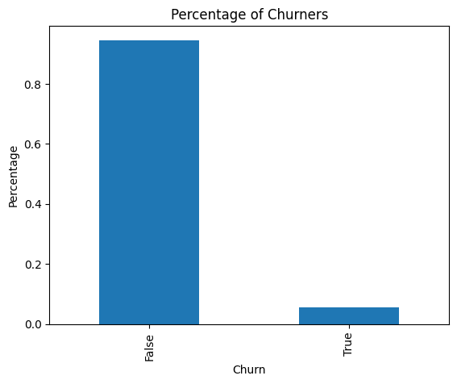

```python
# Explore the target variable: Create a bar chart to show the percentage of churners
# Let's first create a result where we get the percentage of churners and those who don't chrun
# Once we complete that, we will then plot percentage of churners
df_churn['churn'].value_counts(normalize=True).plot(kind='bar', title = 'Percentage of Churners', xlabel = 'Churn', ylabel = 'Percentage')
```

Here we have a barplot for the percentage of churners, and we find that majority of the customers do not churn. This is important as this remains true to our previous findings about churn, and that churn does not seem to really have a big impact on other variables or vice versa. So again, this chart will serve as evidence.

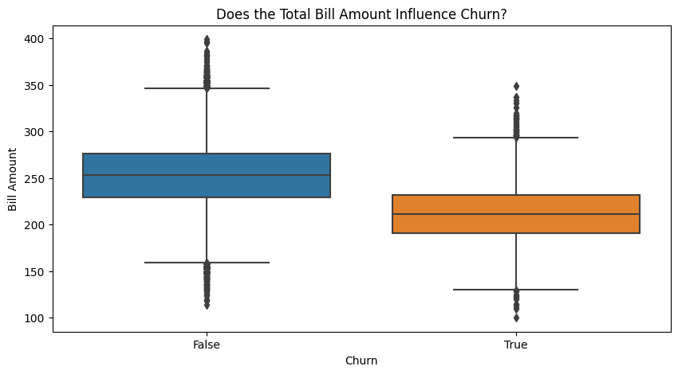

```python
# Explore numerical variables: Create three boxplots to inform the following questions (Be sure to explain your reasoning based on the chart)
# Does the total bill amount influence churn?
plt.figure(figsize=(10,5))
sns.boxplot(data=df_churn,
            x='churn',
            y='total_billed')
plt.title('Does the Total Bill Amount Influence Churn?')
plt.xlabel('Churn')
plt.xticks(rotation=0)
plt.ylabel('Bill Amount')
plt.show()
```

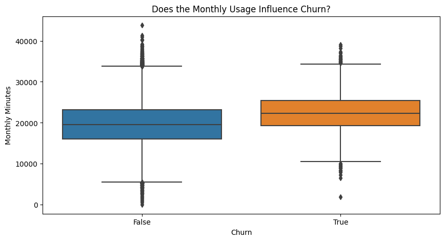

```python
# Does monthly usage influence churn?
plt.figure(figsize=(10,5))
sns.boxplot(data=df_churn,
            x='churn',
            y='monthly_minutes')
plt.title('Does the Monthly Usage Influence Churn?')
plt.xlabel('Churn')
plt.xticks(rotation=0)
plt.ylabel('Monthly Minutes')
plt.show()
```

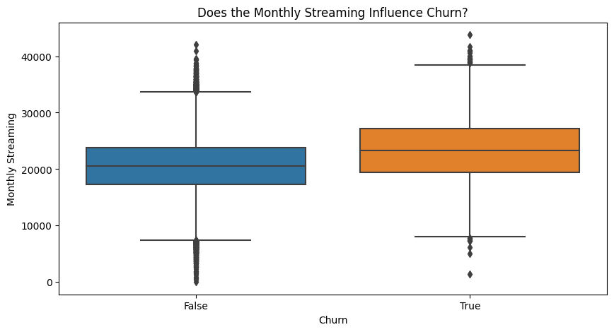

```python
# Does monthly streaming influence churn?
plt.figure(figsize=(10,5))
sns.boxplot(data=df_churn,
            x='churn',
            y='streaming_minutes')
plt.title('Does the Monthly Streaming Influence Churn?')
plt.xlabel('Churn')
plt.xticks(rotation=0)
plt.ylabel('Monthly Streaming')
plt.show()
```

```python
# Matplot.lib version for cross tabulation
ctab3 = pd.crosstab(index=df_churn['network_speed'],
            columns=df_churn['churn'],
            normalize='index').reset_index()
ctab3
```

| churn | network_speed | False | True |
| --- | --- | --- | --- |
| 0 | 4Glte | 0.944118 | 0.055882 |
| 1 | 5G | 0.946431 | 0.053569 |

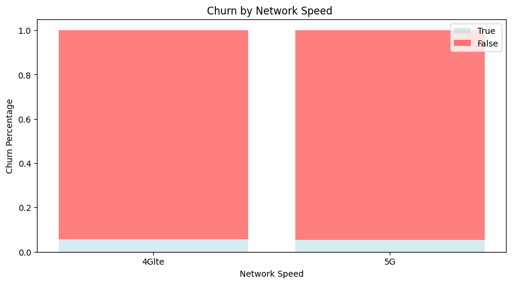

```python
# Matplot Lib Cross Tabulation, Stacked Bar Charts
plt.figure(figsize=(10,5))
# Sort the values in ascending order and we are sorting by False
ctab3.sort_values(False,inplace=True)
# -- check out bottom option, this stacks our bars.
plt.bar(x=ctab3['network_speed'],
        height=ctab3[True],
 			facecolor='lightblue', alpha=0.5, label="True")
plt.bar(x=ctab3['network_speed'],
        height=ctab3[False],
		    bottom=ctab3[True],     # bottom refers to the second height of the bar plot
             facecolor='red', alpha=0.5, label="False")
plt.title('Churn by Network Speed ')
plt.ylabel('Churn Percentage')
plt.xlabel('Network Speed')
plt.xticks(rotation=0)
plt.legend()
plt.show()
```

Network Speed does not seem to influence Churn as the two stacked barplots are roughly similar in size and show that there is no difference in churning based on what Network Speed is being used. 4GLTE and 5G both high perfomring networking speeds, but there might be a huge difference in performance between the two, we could assume. The percentage for churning across both Network Speeds is roughly 5% or 0.05, so not very likely or playing a huge role.

This is just an extra graph

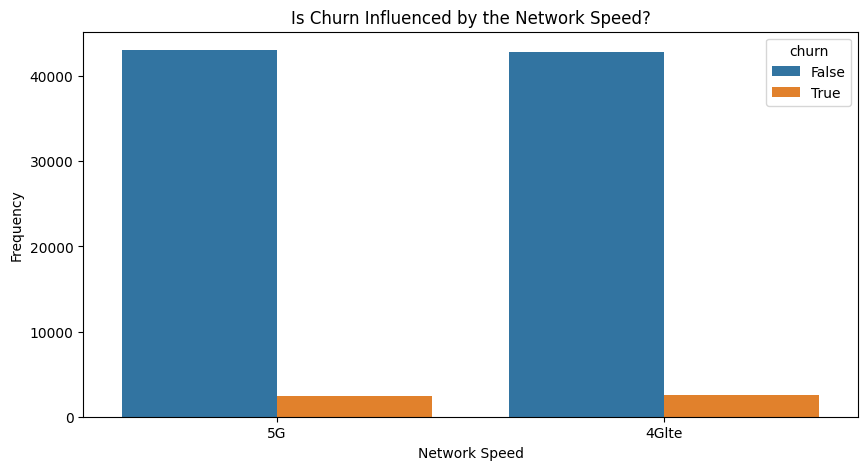

```python
# Explore categorical variables:
# The company believes churn is influenced by the network speed (5G or 4G LTE)
# network_speed
# Count Plot
plt.figure(figsize=(10,5))
sns.countplot(data=df_churn,
            x='network_speed',
            hue='churn')
plt.title('Is Churn Influenced by the Network Speed?')
plt.xlabel('Network Speed')
plt.xticks(rotation=0)
plt.ylabel('Frequency')
plt.show()
```

```python
# Matplot.lib version for cross tabulation
ctab = pd.crosstab(index=df_churn['phone_model'],
            columns=df_churn['churn'],
            normalize='index').reset_index()
ctab
```

| churn | phone_model | False | True |
| --- | --- | --- | --- |
| 0 | Google Pixel 4 XL | 1.000000 | 0.000000 |
| 1 | Google Pixel 4a | 0.924051 | 0.075949 |
| 2 | Moto G8 Power | 0.949520 | 0.050480 |
| 3 | OnePlus 7 Pro | 1.000000 | 0.000000 |
| 4 | OnePlus 8 Pro | 0.940212 | 0.059788 |
| 5 | Samsung Galaxy Note 20 Ultra | 0.959917 | 0.040083 |
| 6 | Samsung Galaxy S10 / S10 Plus | 0.943927 | 0.056073 |
| 7 | Samsung Galaxy S10e | 0.944002 | 0.055998 |
| 8 | Samsung Galaxy S20 / S20 Plus | 0.933252 | 0.066748 |
| 9 | Samsung Galaxy S20 Ultra | 0.942876 | 0.057124 |
| 10 | iPhone 11 | 0.971429 | 0.028571 |
| 11 | iPhone 11 Pro / Pro Max | 1.000000 | 0.000000 |
| 12 | iPhone SE 2020 | 0.949109 | 0.050891 |
| 13 | iPhone XR | 0.984749 | 0.015251 |
| 14 | iPhone XS | 0.947320 | 0.052680 |

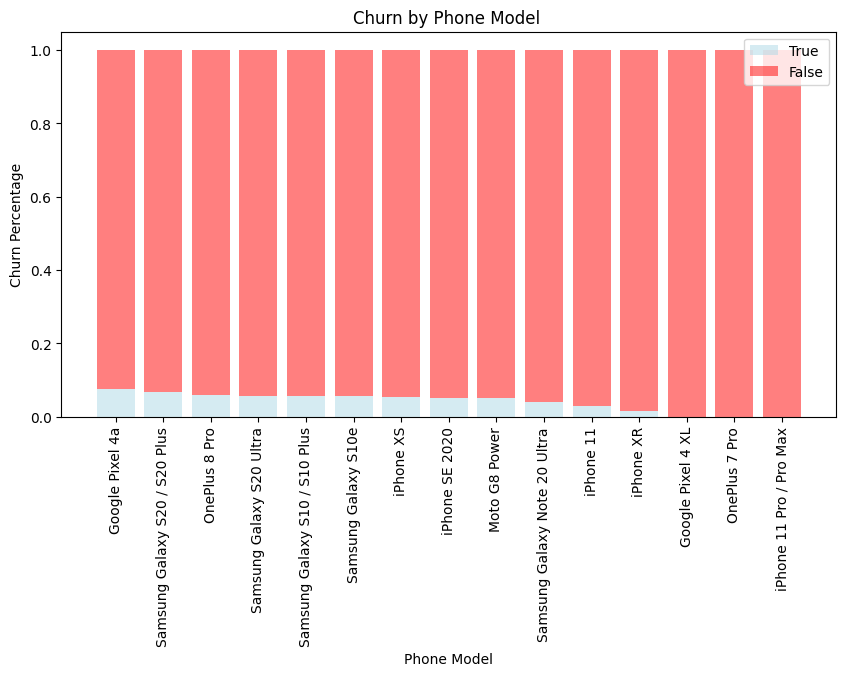

```python
# Matplot Lib Cross Tabulation, Stacked Bar Charts
plt.figure(figsize=(10,5))
# Sort the values in ascending order and we are sorting by False
ctab.sort_values(False,inplace=True)
# -- check out bottom option, this stacks our bars.
plt.bar(x=ctab['phone_model'],
        height=ctab[True],
 			facecolor='lightblue', alpha=0.5, label=True)
plt.bar(x=ctab['phone_model'],
        height=ctab[False],
		    bottom=ctab[True],     # bottom refers to the second height of the bar plot
             facecolor='red', alpha=0.5, label=False)
plt.title('Churn by Phone Model ')
plt.ylabel('Churn Percentage')
plt.xlabel('Phone Model')
plt.xticks(rotation=90)
plt.legend()
plt.show()
```

```python
# Matplot.lib version for cross tabulation
ctab2 = pd.crosstab(index=df_churn['paperless_billing'],
            columns=df_churn['churn'],
            normalize='index').reset_index()
ctab2
```

| churn | paperless_billing | False | True |
| --- | --- | --- | --- |
| 0 | No | 0.923291 | 0.076709 |
| 1 | Yes | 0.969721 | 0.030279 |

[figure not shown]

```python
# Paperless Billing
plt.figure(figsize=(10,5))
# Sort the values in ascending order and we are sorting by False
ctab2.sort_values(False,inplace=True)
# -- check out bottom option, this stacks our bars.
plt.bar(x=ctab2['paperless_billing'],
        height=ctab2[True],
 			facecolor='lightblue', alpha=0.5, label='False')
plt.bar(x=ctab2['paperless_billing'],
        height=ctab2[False],
		    bottom=ctab2[True],     # bottom refers to the second height of the bar plot
             facecolor='red', alpha=0.5, label="True")
plt.title('Churn by Paperless Billing ')
plt.ylabel('Churn Percentage')
plt.xlabel('Paperless Billing')
plt.xticks(rotation=0)
plt.legend()                # This helps with showing our labels
plt.show()
```

```python
# Cross tab for Phone Service, Phone Service
ctab4 = pd.crosstab(index=df_churn['customer_service_calls'],
                    columns=df_churn['churn'],
                    normalize='index').reset_index()
ctab4
```

| churn | customer_service_calls | False | True |
| --- | --- | --- | --- |
| 0 | 0.0 | 0.925926 | 0.074074 |
| 1 | 1.0 | 0.947085 | 0.052915 |
| 2 | 2.0 | 0.944304 | 0.055696 |
| 3 | 3.0 | 0.947611 | 0.052389 |
| 4 | 4.0 | 0.953488 | 0.046512 |

[figure not shown]

```python
# Explore any relationships of your interest (i.e. things you found interesting that may influence customer churn).
# Provide 3-4 Key findings based on your charts.
# Customer Service Calls
plt.figure(figsize=(10,5))
# Sort the values in ascending order and we are sorting by False
ctab4.sort_values(False,inplace=True)
# -- check out bottom option, this stacks our bars.
plt.bar(x=ctab4['customer_service_calls'],
        height=ctab4[True],
 			facecolor='lightblue', alpha=0.5, label='False')
plt.bar(x=ctab4['customer_service_calls'],
        height=ctab4[False],
		    bottom=ctab4[True],     # bottom refers to the second height of the bar plot
             facecolor='red', alpha=0.5, label="True")
plt.title('Churn by Customer Service Calls ')
plt.ylabel('Churn Percentage')
plt.xlabel('Number of Customer Service Calls')
plt.xticks(rotation=0)
plt.legend()                # This helps with showing our labels
plt.show()
```

Your Findings:

## Finally

Wrap this up in a notebook and convert it to **HTML**, to exceed the bar - make sure things look good.